# Energ

# Analysis on India

```python
IndiaPowerPlants = GlobalPowerPlantDataset[GlobalPowerPlantDataset['country_long'] == 'India']
```

```python
print(f'Total Power Plants In India : {len(IndiaPowerPlants)}')
```

```
Total Power Plants In India : 1589
```

```python
types_of_powerplant_india  = IndiaPowerPlants.groupby('primary_fuel').agg({'name of powerplant':['count'],'capacity in MW': ['sum']}).reset_index()
```

```python
types_of_powerplant_india['percentage_contribution'] = (types_of_powerplant_india[('capacity in MW', 'sum')] / types_of_powerplant_india[('capacity in MW', 'sum')].sum()) * 100
```

```python
types_of_powerplant_india.sort_values(by=('capacity in MW', 'sum'), ascending=False)
```

|  | primary_fuel | name of powerplant count | capacity in MW sum | percentage_contribution |
| --- | --- | --- | --- | --- |
| 1 | Coal | 253 | 204919.22 | 64.83 |
| 3 | Hydro | 233 | 45561.47 | 14.41 |
| 6 | Solar | 851 | 25549.10 | 8.08 |
| 2 | Gas | 68 | 24947.51 | 7.89 |
| 4 | Nuclear | 9 | 8780.00 | 2.78 |
| 7 | Wind | 108 | 3647.15 | 1.15 |
| 5 | Oil | 17 | 1680.84 | 0.53 |
| 0 | Biomass | 50 | 1003.26 | 0.32 |

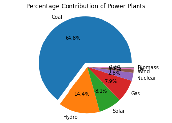

```python
types_of_powerplant_india.sort_values('percentage_contribution',ascending=False,inplace=True)
# Assuming df is your DataFrame with the percentage contribution column
labels = types_of_powerplant_india['primary_fuel']
sizes = types_of_powerplant_india['percentage_contribution']
explode = (0.1, 0, 0, 0, 0, 0, 0, 0)  # Explode the 1st slice (Coal)
fig1, ax1 = plt.subplots()
ax1.pie(sizes, explode=explode, labels=labels, autopct='%1.1f%%', startangle=0)
ax1.axis('equal')  # Equal aspect ratio ensures that pie is drawn as a circle.

plt.title('Percentage Contribution of Power Plants')
plt.show()
```

### India is Dominated by Coal for Electricity Generation with 64.8% Generation from Coal

#### Total Coal Plant's are around 253

##### 1. It's MW Generation is More.

##### 2. It's means More Power is generated with less Plants.

##### 3. Coal generation is Cost effective.

```python
IndiaPowerPlants['primary_fuel'].unique()
```

```
array(['Solar', 'Coal', 'Wind', 'Gas', 'Hydro', 'Biomass', 'Oil',
       'Nuclear'], dtype=object)
```

#### Tops 5 Power Plants in India based on capacity in MW

```python
IndiaPowerPlants.sort_values('capacity in MW',ascending=False).head(5)[['country code', 'country_long', 'name of powerplant', 'capacity in MW',
       'primary_fuel', 'secondary fuel']]
```

|  | country code | country_long | name of powerplant | capacity in MW | primary_fuel | secondary fuel |
| --- | --- | --- | --- | --- | --- | --- |
| 15586 | IND | India | VINDH_CHAL STPS | 4760.00 | Coal | Oil |
| 14929 | IND | India | MUNDRA TPP | 4620.00 | Coal | Oil |
| 14930 | IND | India | MUNDRA UMPP | 4000.00 | Coal | Oil |
| 15312 | IND | India | SASAN UMPP | 3960.00 | Coal | Oil |
| 15473 | IND | India | TIRORA TPP | 3300.00 | Coal | Oil |

#### Tops 5 Solar Power Plants in India based on capacity in MW

```python
IndiaPowerPlants[IndiaPowerPlants['primary_fuel'] == 'Solar'].sort_values('capacity in MW',ascending=False).head(5)[['country code', 'country_long', 'name of powerplant', 'capacity in MW',
       'primary_fuel', 'secondary fuel']]
```

|  | country code | country_long | name of powerplant | capacity in MW | primary_fuel | secondary fuel |
| --- | --- | --- | --- | --- | --- | --- |
| 14774 | IND | India | Kamuthi Solar Power Plant | 648.00 | Solar | NaN |
| 14252 | IND | India | BhSP3 | 560.00 | Solar | NaN |
| 15052 | IND | India | NPKSP} Greenko | 500.00 | Solar | NaN |
| 14720 | IND | India | KUMSP} Greenko | 500.00 | Solar | NaN |
| 14240 | IND | India | BhSP1 | 420.00 | Solar | NaN |

```python
megawatt_power_generated_by_coal_plants = types_of_powerplant_india[types_of_powerplant_india['primary_fuel'] == 'Coal'].iloc[0]['capacity in MW']['sum']
megawatt_power_generated_by_solar_plants = types_of_powerplant_india[types_of_powerplant_india['primary_fuel'] == 'Solar'].iloc[0]['capacity in MW']['sum']
solar_power_plant_count = types_of_powerplant_india[types_of_powerplant_india['primary_fuel'] == 'Solar'].iloc[0]['name of powerplant']['count']
solar_plant_to_increase_power_generation_percent = megawatt_power_generated_by_coal_plants/megawatt_power_generated_by_solar_plants
```

```python
new_solar_power_plants = solar_power_plant_count * solar_plant_to_increase_power_generation_percent
print(f"New Solar Power Plants to Match Caol Power Generation : {int(new_solar_power_plants)}")
```

```
New Solar Power Plants to Match Caol Power Generation : 6825
```

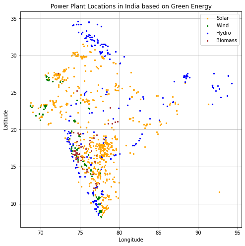

```python
Renuable_India_PowerPlants = IndiaPowerPlants[IndiaPowerPlants.primary_fuel.isin(['Solar', 'Wind', 'Hydro', 'Biomass'])]
filtered_data = Renuable_India_PowerPlants[['latitude', 'longitude', 'primary_fuel']]
unique_fuels = filtered_data['primary_fuel'].unique()
fuel_colors = {'Solar':'orange', 'Wind':'green', 'Hydro':'blue', 'Biomass':'brown'}
plt.figure(figsize=(8, 8))

for fuel in unique_fuels:
    fuel_data = filtered_data[filtered_data['primary_fuel'] == fuel]
    color = fuel_colors[fuel]
    plt.scatter(
        fuel_data['longitude'],
        fuel_data['latitude'],
        marker='o',
        s=5,
        alpha=1,
        color=color,
        label=fuel
    )

plt.title('Power Plant Locations in India based on Green Energy')
plt.xlabel('Longitude')
plt.ylabel('Latitude')
plt.grid(True)
plt.legend()
plt.show()
```

### Synergizing Sustainable Energy

##### The chart provided illustrates the presence of power plants using different energy sources, specifically Hydro, Wind, Solar, and Biomass. However, it's important to understand the dynamic relationship between these energy sources.

##### Hydro power plants are known for their ability to store water below a reservoir during periods of excess energy production, often during the daytime. This stored water represents potential energy that can be converted into kinetic energy when needed.

##### To optimize the utilization of this potential energy, Wind, Solar, and Biomass power sources play a crucial role. During the daytime, when energy production from these sources is abundant, they can collectively power the Hydro project. This surplus energy can be used to pump water back to the top of the reservoir, effectively converting kinetic energy into potential energy. This process essentially "recharges" the Hydro project, making it ready to generate electricity during periods of high demand, such as at night.

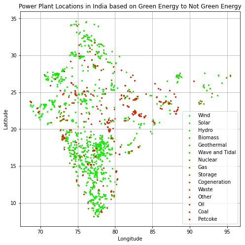

```python
filtered_data = IndiaPowerPlants[['latitude', 'longitude', 'primary_fuel']]

unique_fuels = filtered_data['primary_fuel'].unique()

unique_fuels = [
    'Wind',
    'Solar',
    'Hydro',
    'Biomass',
    'Geothermal',
    'Wave and Tidal',
    'Nuclear',
    'Gas',
    'Storage',
    'Cogeneration',
    'Waste',
    'Other',
    'Oil',
    'Coal',
    'Petcoke'
]

# Generate a colormap that transitions from green to red
n = len(unique_fuels)
colors = [(i/n, 1-i/n, 0) for i in range(n)]
cmap = mcolors.LinearSegmentedColormap.from_list('green_to_red', colors, N=n)

# Assign colors to each fuel
fuel_colors = {fuel: cmap(i/n) for i, fuel in enumerate(unique_fuels)}

# Create a scatter plot with random colors for each fuel type
# plt.figure(figsize=(18, 8))
plt.figure(figsize=(8, 8))

for fuel in unique_fuels:
    fuel_data = filtered_data[filtered_data['primary_fuel'] == fuel]
    color = fuel_colors[fuel]
    plt.scatter(
        fuel_data['longitude'],
        fuel_data['latitude'],
        marker='o',
        s=5,
        alpha=1,
        color=color,
        label=fuel
    )

plt.title('Power Plant Locations in India based on Green Energy to Not Green Energy')
plt.xlabel('Longitude')
plt.ylabel('Latitude')
plt.grid(True)
plt.legend()
plt.show()
```

# Global Power Plant Analysis

```python
GlobalPowerPlantDataset.sort_values('capacity in MW', ascending = False).head(5)[['country code', 'country_long', 'name of powerplant', 'capacity in MW',
       'primary_fuel', 'secondary fuel']]
```

|  | country code | country_long | name of powerplant | capacity in MW | primary_fuel | secondary fuel |
| --- | --- | --- | --- | --- | --- | --- |
| 8453 | CHN | China | Three Gorges Dam | 22500.00 | Hydro | NaN |
| 5137 | CHN | China | Baihetan Dam | 13050.00 | Hydro | NaN |
| 8755 | CHN | China | Xiluodu | 12600.00 | Hydro | NaN |
| 19603 | RUS | Russia | Surgutskaya GRES-2 | 8865.00 | Gas | NaN |
| 34668 | VEN | Venezuela | Simon Bolivar (Guri) | 8851.00 | Hydro | NaN |

### Power Plant Distribution Based on Capicity in MW across Globe.

#### China Has largest Power Plants intrestingly those is Hydro wihich are Green Energy

### Total Types of Power Plant across Globe

```python
GlobalPowerPlantDataset.primary_fuel.unique()
```

```
array(['Hydro', 'Solar', 'Gas', 'Other', 'Oil', 'Wind', 'Nuclear', 'Coal',
       'Waste', 'Biomass', 'Wave and Tidal', 'Petcoke', 'Geothermal',
       'Storage', 'Cogeneration'], dtype=object)
```

### Pie Chart Based on Count and Capicity

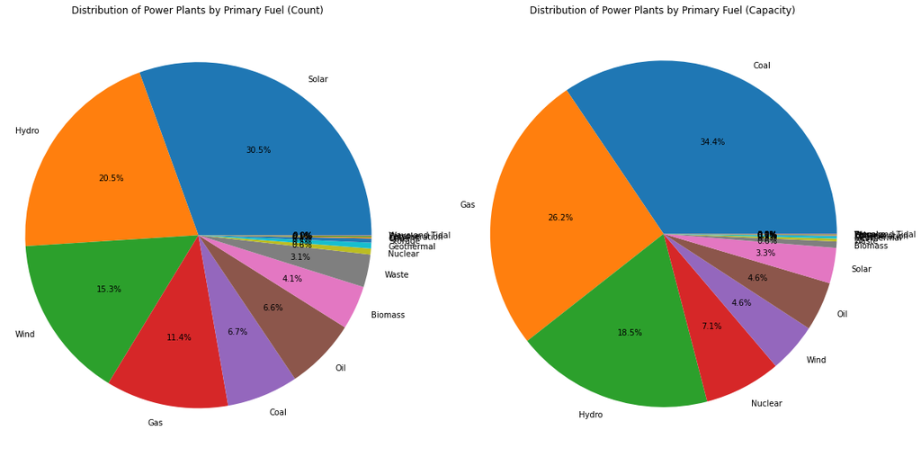

```python
import matplotlib.pyplot as plt

fig, axes = plt.subplots(1, 2, figsize=(16, 8))

# First Pie Chart - Distribution of Power Plants by Count
PowerPlantCount = GlobalPowerPlantDataset.groupby('primary_fuel').count()['name of powerplant'].reset_index().sort_values('name of powerplant', ascending=False)
axes[0].pie(PowerPlantCount['name of powerplant'], labels=PowerPlantCount['primary_fuel'], autopct='%1.1f%%', startangle=0)
axes[0].set_title("Distribution of Power Plants by Primary Fuel (Count)")
axes[0].axis('equal')

# Second Pie Chart - Distribution of Power Plants by Capacity
PowerPlantCapacity = GlobalPowerPlantDataset.groupby('primary_fuel').sum()['capacity in MW'].reset_index().sort_values('capacity in MW', ascending=False)
axes[1].pie(PowerPlantCapacity['capacity in MW'], labels=PowerPlantCapacity['primary_fuel'], autopct='%1.1f%%', startangle=0)
axes[1].set_title("Distribution of Power Plants by Primary Fuel (Capacity)")
axes[1].axis('equal')

plt.tight_layout()
plt.show()
```

### Map Shows Power Plant Distribution Based on Green to Not Green Energy

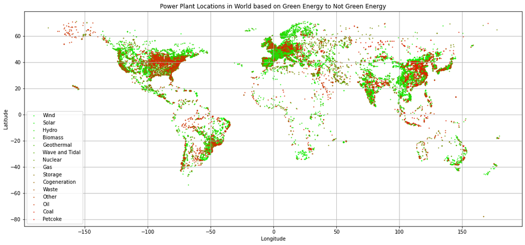

```python
filtered_data = GlobalPowerPlantDataset[['latitude', 'longitude', 'primary_fuel']]
unique_fuels = filtered_data['primary_fuel'].unique()
unique_fuels = [
    'Wind',
    'Solar',
    'Hydro',
    'Biomass',
    'Geothermal',
    'Wave and Tidal',
    'Nuclear',
    'Gas',
    'Storage',
    'Cogeneration',
    'Waste',
    'Other',
    'Oil',
    'Coal',
    'Petcoke'
]

n = len(unique_fuels)
colors = [(i/n, 1-i/n, 0) for i in range(n)]
cmap = mcolors.LinearSegmentedColormap.from_list('green_to_red', colors, N=n)


fuel_colors = {fuel: cmap(i/n) for i, fuel in enumerate(unique_fuels)}


plt.figure(figsize=(18, 8))
# plt.figure(figsize=(8, 8))

for fuel in unique_fuels:
    fuel_data = filtered_data[filtered_data['primary_fuel'] == fuel]
    color = fuel_colors[fuel]
    plt.scatter(
        fuel_data['longitude'],
        fuel_data['latitude'],
        marker='o',
        s=1,
        alpha=1,
        color=color,
        label=fuel
    )

plt.title('Power Plant Locations in World based on Green Energy to Not Green Energy')
plt.xlabel('Longitude')
plt.ylabel('Latitude')
plt.grid(True)
plt.legend()
plt.show()
```

##### Green Means Greener Energy like Wind, Solar, Hydro etc

##### Red Means Petcoke, Coal, Oil etc

##### It looks USA has a lot of Non Green Power Plants.

```python
GlobalPowerPlantDataset.groupby(['country_long'])['capacity in MW'].sum().sort_values(ascending = False).head(5)
```

```
country_long
China                      1415067.38
United States of America   1204638.05
India                       316088.55
Russia                      228220.05
Japan                       215365.85
Name: capacity in MW, dtype: float64
```

```python
GlobalPowerPlantDataset.groupby(['country_long'])['capacity in MW'].sum().sort_values(ascending = False).tail(5)
```

```
country_long
Guinea-Bissau   18.24
Antarctica       7.60
Palestine        7.60
Suriname         5.00
Saint Lucia      3.00
Name: capacity in MW, dtype: float64
```

```python
GlobalPowerPlantDataset[GlobalPowerPlantDataset['country_long'] == 'China'].groupby('primary_fuel').sum()['capacity in MW'].sort_values(ascending = False)
```

```
primary_fuel
Coal         955718.00
Hydro        259025.60
Gas           59774.50
Solar         54801.82
Wind          50990.36
Nuclear       33402.00
Oil            1329.00
Geothermal       26.10
Name: capacity in MW, dtype: float64
```

```python
GlobalPowerPlantDataset[GlobalPowerPlantDataset['country_long'] == 'United States of America'].groupby('primary_fuel').sum()['capacity in MW'].sort_values(ascending = False)
```

```
primary_fuel
Gas            546435.80
Coal           249149.10
Wind           104476.90
Nuclear        104233.10
Hydro          101656.90
Solar           37970.35
Oil             37143.40
Waste            9768.50
Biomass          5123.20
Geothermal       3889.20
Petcoke          2361.60
Cogeneration     1042.00
Storage           815.60
Other             572.40
Name: capacity in MW, dtype: float64
```

```python
GlobalPowerPlantDataset[GlobalPowerPlantDataset['country_long'] == 'India'].groupby('primary_fuel').sum()['capacity in MW'].sort_values(ascending = False)
```

```
primary_fuel
Coal      204919.22
Hydro      45561.47
Solar      25549.10
Gas        24947.51
Nuclear     8780.00
Wind        3647.15
Oil         1680.84
Biomass     1003.26
Name: capacity in MW, dtype: float64
```

```python
GlobalPowerPlantDataset[GlobalPowerPlantDataset['country_long'] == 'Japan'].groupby('primary_fuel').sum()['capacity in MW'].sort_values(ascending = False)
```

```
primary_fuel
Gas          53362.75
Oil          44120.20
Nuclear      42537.00
Coal         41513.00
Hydro        27439.00
Solar         5686.60
Geothermal     536.30
Wind           150.00
Waste           21.00
Name: capacity in MW, dtype: float64
```

```python
GlobalPowerPlantDataset[GlobalPowerPlantDataset['primary_fuel'] == 'Nuclear'].sort_values('capacity in MW',ascending = False)['capacity in MW']
```

```
16625   8212.00
21926   6000.00
20053   5900.00
20051   5900.00
10975   5460.00
          ...
101      370.00
18209    137.00
14395    100.00
19212     48.00
5258      20.00
Name: capacity in MW, Length: 195, dtype: float64
```

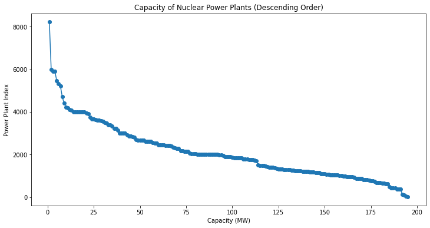

```python
import matplotlib.pyplot as plt

# Filter the data for Nuclear power plants and sort by capacity in MW in descending order
nuclear_data = GlobalPowerPlantDataset[GlobalPowerPlantDataset['primary_fuel'] == 'Nuclear'].sort_values('capacity in MW', ascending=False)

# Create a horizontal line plot
plt.figure(figsize=(12, 6))
plt.plot(range(1, len(nuclear_data) + 1), nuclear_data['capacity in MW'],  marker='o', linestyle='-')
plt.title("Capacity of Nuclear Power Plants (Descending Order)")
plt.xlabel("Capacity (MW)")
plt.ylabel("Power Plant Index")

# Show the plot
plt.show()
```

```python
nuclear_data.describe()
```

|  | capacity in MW | latitude | longitude | start date | generation_gwh_2021 | estimated_generation_gwh_2021 |
| --- | --- | --- | --- | --- | --- | --- |
| count | 195.00 | 195.00 | 195.00 | 98.00 | 58.00 | 0.00 |
| mean | 2091.86 | 38.57 | 4.62 | 1983.87 | 13916.30 | NaN |
| std | 1303.51 | 16.04 | 79.02 | 9.98 | 6086.52 | NaN |
| min | 20.00 | -33.97 | -120.86 | 1964.00 | 4964.57 | NaN |
| 25% | 1146.65 | 34.66 | -77.90 | 1976.00 | 8454.20 | NaN |
| 50% | 1888.00 | 41.24 | 4.73 | 1984.00 | 14444.87 | NaN |
| 75% | 2668.35 | 47.73 | 64.06 | 1987.00 | 18968.78 | NaN |
| max | 8212.00 | 68.05 | 166.54 | 2015.00 | 31920.37 | NaN |

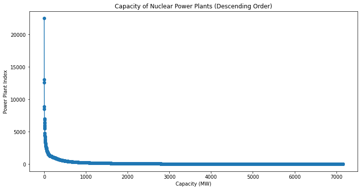

```python
import matplotlib.pyplot as plt

# Filter the data for Nuclear power plants and sort by capacity in MW in descending order
nuclear_data = GlobalPowerPlantDataset[GlobalPowerPlantDataset['primary_fuel'] == 'Hydro'].sort_values('capacity in MW', ascending=False)

# Create a horizontal line plot
plt.figure(figsize=(12, 6))
plt.plot(range(1, len(nuclear_data) + 1), nuclear_data['capacity in MW'],  marker='o', linestyle='-')
plt.title("Capacity of Nuclear Power Plants (Descending Order)")
plt.xlabel("Capacity (MW)")
plt.ylabel("Power Plant Index")

# Show the plot
plt.show()
```

```python
nuclear_data.describe()
```

|  | capacity in MW | latitude | longitude | start date | generation_gwh_2021 | estimated_generation_gwh_2021 |
| --- | --- | --- | --- | --- | --- | --- |
| count | 7156.00 | 7156.00 | 7156.00 | 3797.00 | 1419.00 | 7108.00 |
| mean | 147.17 | 30.33 | -5.46 | 1973.72 | 198.87 | 472.55 |
| std | 549.81 | 26.07 | 78.83 | 30.56 | 870.90 | 1761.00 |
| min | 1.00 | -53.79 | -159.63 | 1896.00 | -780.34 | 1.59 |
| 25% | 5.40 | 23.34 | -73.70 | 1953.00 | 7.96 | 17.18 |
| 50% | 20.00 | 39.68 | 1.27 | 1979.00 | 25.34 | 70.72 |
| 75% | 93.60 | 46.31 | 69.38 | 2001.00 | 113.65 | 307.90 |
| max | 22500.00 | 70.37 | 178.05 | 2019.00 | 16909.30 | 48675.06 |

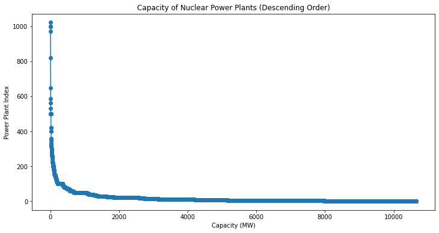

```python
import matplotlib.pyplot as plt

# Filter the data for Nuclear power plants and sort by capacity in MW in descending order
nuclear_data = GlobalPowerPlantDataset[GlobalPowerPlantDataset['primary_fuel'] == 'Solar'].sort_values('capacity in MW', ascending=False)

# Create a horizontal line plot
plt.figure(figsize=(12, 6))
plt.plot(range(1, len(nuclear_data) + 1), nuclear_data['capacity in MW'],  marker='o', linestyle='-')
plt.title("Capacity of Nuclear Power Plants (Descending Order)")
plt.xlabel("Capacity (MW)")
plt.ylabel("Power Plant Index")

# Show the plot
plt.show()
```

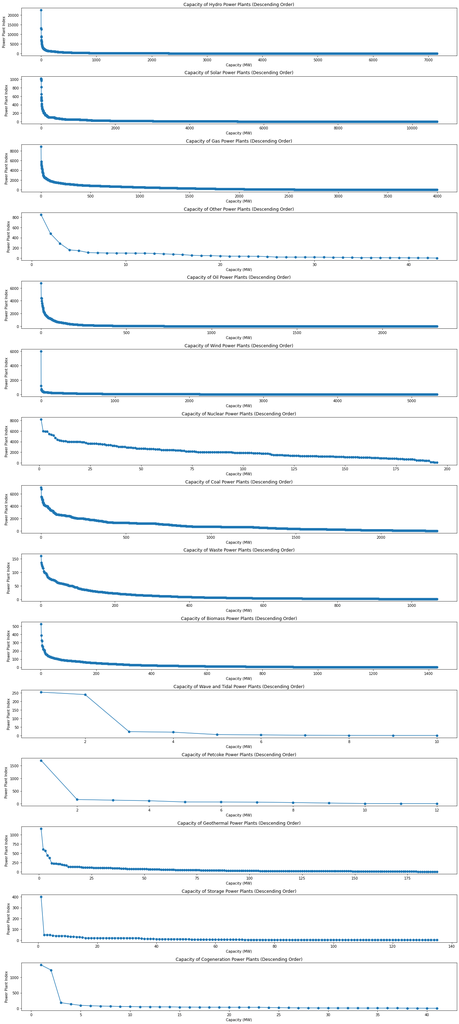

```python
import matplotlib.pyplot as plt

# Get unique primary fuel types
unique_fuels = GlobalPowerPlantDataset['primary_fuel'].unique()

# Create a figure with subplots
fig, axes = plt.subplots(len(unique_fuels), 1 , figsize=(18, 40))

# Loop through each unique primary fuel type
for i, fuel in enumerate(unique_fuels):
    # Filter the data for power plants with the current primary fuel and sort by capacity in MW
    fuel_data = GlobalPowerPlantDataset[GlobalPowerPlantDataset['primary_fuel'] == fuel].sort_values('capacity in MW', ascending=False)

    # Create a horizontal line plot for the current primary fuel
    axes[i].plot(range(1, len(fuel_data) + 1), fuel_data['capacity in MW'], marker='o', linestyle='-')
    axes[i].set_title(f"Capacity of {fuel} Power Plants (Descending Order)")
    axes[i].set_xlabel("Capacity (MW)")
    axes[i].set_ylabel("Power Plant Index")

# Adjust the layout
plt.tight_layout()

# Show the plots
plt.show()
```

```python
# Assuming that 'country_long' and 'primary_fuel' are the index and columns of your DataFrame.
# You can reset the index and then sort by the sum of capacity in MW for each country.

sorted_data = GlobalPowerPlantDataset.reset_index().groupby('country_long')['capacity in MW'].sum().reset_index()
sorted_data = sorted_data.sort_values(by='capacity in MW', ascending=False)

# The sorted_data DataFrame will now be sorted based on the maximum sum of capacity in MW for each country.
```

```python
sorted_data
```

|  | country_long | capacity in MW |
| --- | --- | --- |
| 30 | China | 1415067.38 |
| 158 | United States of America | 1204638.05 |
| 67 | India | 316088.55 |
| 125 | Russia | 228220.05 |
| 75 | Japan | 215365.85 |
| ... | ... | ... |
| 62 | Guinea-Bissau | 18.24 |
| 4 | Antarctica | 7.60 |
| 115 | Palestine | 7.60 |
| 140 | Suriname | 5.00 |
| 127 | Saint Lucia | 3.00 |

167 rows × 2 columns

```python
unique_fuels
```

```
array(['Hydro', 'Solar', 'Gas', 'Other', 'Oil', 'Wind', 'Nuclear', 'Coal',
       'Waste', 'Biomass', 'Wave and Tidal', 'Petcoke', 'Geothermal',
       'Storage', 'Cogeneration'], dtype=object)
```

```python
fuel_colors
```

[output not shown]

```python
data = {
    'Solar': 'darkgreen',
    'Wind': 'green',
    'Hydro': 'lightgreen',
    'Biomass': 'lightcoral',
    'Hydro': np.array([0.16654584, 0.64655379, 0.76817084]),
    'Biomass': np.array([0.70409905, 0.57128103, 0.12135012]),
    'Oil': np.array([0.4572532, 0.115147 , 0.9249063]),
    'Nuclear': np.array([0.42968116, 0.80070875, 0.49658533])
}

Solar
Wind
Hydro
Biomass
Nuclear
Coal

# Define a colormap with green and red shades
colors = ['darkred', 'red', 'lightcoral', 'lightgreen', 'green', 'darkgreen']
cmap = plt.cm.colors.ListedColormap(colors)
```

```python
fuel_colors = {fuel: np.random.rand(3,) for fuel in unique_fuels}
fuel_colors
```

[output not shown]

```python
x = {'Solar': array([0.36385664, 0.73603912, 0.75711853]),
 'Coal': array([0.37785911, 0.31873043, 0.3299339 ]),
 'Wind': array([0.74555782, 0.43051331, 0.02754045]),
 'Gas': array([0.49010884, 0.74209762, 0.68565044]),
 'Hydro': array([0.16654584, 0.64655379, 0.76817084]),
 'Biomass': array([0.70409905, 0.57128103, 0.12135012]),
 'Oil': array([0.4572532, 0.115147 , 0.9249063]),
 'Nuclear': array([0.42968116, 0.80070875, 0.49658533])}
```

```python
IndiaPowerPlants[IndiaPowerPlants['primary_fuel'] == 'Wind'][['name of powerplant', 'latitude', 'longitude', 'primary_fuel']]
```

[output not shown]

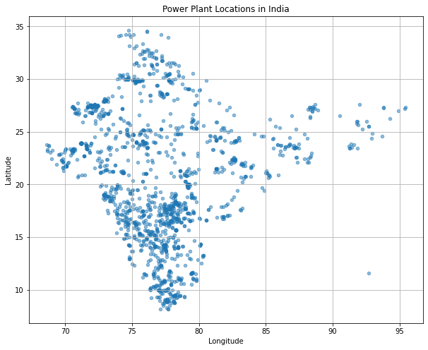

```python
coordinates = IndiaPowerPlants[['latitude', 'longitude']]
plt.figure(figsize=(10, 8))
plt.scatter(coordinates['longitude'], coordinates['latitude'], marker='o', s=20, alpha=0.5)
plt.title('Power Plant Locations in India')
plt.xlabel('Longitude')
plt.ylabel('Latitude')
plt.grid(True)
plt.show()
```

```python
GlobalPowerPlantDataset.groupby('country_long')['name of powerplant'].count().reset_index().sort_values('name of powerplant', ascending = False).head(30)
```

|  | country_long | name of powerplant |
| --- | --- | --- |
| 158 | United States of America | 9833 |
| 30 | China | 4235 |
| 157 | United Kingdom | 2751 |
| 19 | Brazil | 2360 |
| 52 | France | 2155 |
| 67 | India | 1589 |
| 57 | Germany | 1309 |
| 26 | Canada | 1159 |
| 137 | Spain | 829 |
| 125 | Russia | 545 |
| 75 | Japan | 522 |
| 7 | Australia | 486 |
| 122 | Portugal | 469 |
| 38 | Czech Republic | 462 |
| 73 | Italy | 396 |
| 29 | Chile | 315 |
| 112 | Norway | 306 |
| 97 | Mexico | 277 |
| 162 | Vietnam | 236 |
| 5 | Argentina | 236 |
| 148 | Thailand | 196 |
| 121 | Poland | 189 |
| 51 | Finland | 185 |
| 68 | Indonesia | 178 |
| 142 | Sweden | 168 |
| 143 | Switzerland | 168 |
| 152 | Turkey | 163 |
| 136 | South Korea | 132 |
| 120 | Philippines | 123 |
| 69 | Iran | 107 |

[figure not shown]

```python
import pandas as pd
import matplotlib.pyplot as plt
import numpy as np

# Load the data
# data = pd.read_csv("powerplants.csv")

# Filter data for latitude, longitude, and primary_fuel
# filtered_data = GlobalPowerPlantDataset[['latitude', 'longitude', 'primary_fuel']]
filtered_data = IndiaPowerPlants[['latitude', 'longitude', 'primary_fuel']]

# Get unique fuel types
unique_fuels = filtered_data['primary_fuel'].unique()

# Generate random colors for each unique fuel type
fuel_colors = {fuel: np.random.rand(3,) for fuel in unique_fuels}

# Create a scatter plot with random colors for each fuel type
plt.figure(figsize=(10, 8))

for fuel in unique_fuels:
    fuel_data = filtered_data[filtered_data['primary_fuel'] == fuel]
    color = fuel_colors[fuel]
    plt.scatter(
        fuel_data['longitude'],
        fuel_data['latitude'],
        marker='o',
        s=20,
        alpha=1,
        color=color,
        label=fuel
    )

plt.title('Power Plant Locations in India by Primary Fuel Type')
plt.xlabel('Longitude')
plt.ylabel('Latitude')
plt.grid(True)
plt.legend()
plt.show()
```

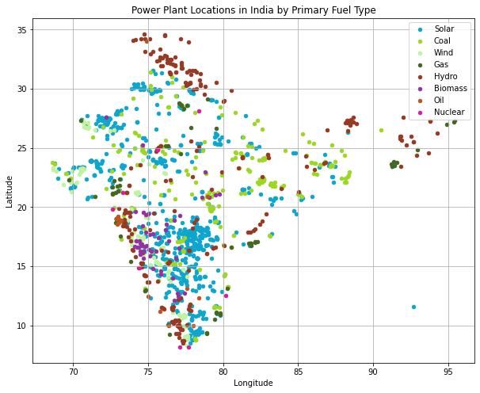

```python
import pandas as pd
import matplotlib.pyplot as plt
import numpy as np

# Load the data
# data = pd.read_csv("powerplants.csv")

# Filter data for latitude, longitude, and primary_fuel
filtered_data = IndiaPowerPlants[['latitude', 'longitude', 'primary_fuel']]

# Get unique fuel types
unique_fuels = filtered_data['primary_fuel'].unique()

# Generate random colors for each unique fuel type
fuel_colors = {fuel: np.random.rand(3,) for fuel in unique_fuels}

# Create a scatter plot with random colors for each fuel type
plt.figure(figsize=(10, 8))

for fuel in unique_fuels:
    fuel_data = filtered_data[filtered_data['primary_fuel'] == fuel]
    color = fuel_colors[fuel]
    plt.scatter(
        fuel_data['longitude'],
        fuel_data['latitude'],
        marker='o',
        s=20,
        alpha=1,
        color=color,
        label=fuel
    )

plt.title('Power Plant Locations in India by Primary Fuel Type')
plt.xlabel('Longitude')
plt.ylabel('Latitude')
plt.grid(True)
plt.legend()
plt.show()
```

```python
IndiaPowerPlants
```

|  | country code | country_long | name of powerplant | capacity in MW | latitude | longitude | primary_fuel | secondary fuel | other_fuel2 | other_fuel3 | start date | owner of plant | generation_gwh_2021 | geolocation_source | estimated_generation_gwh_2021 |
| --- | --- | --- | --- | --- | --- | --- | --- | --- | --- | --- | --- | --- | --- | --- | --- |
| 14052 | IND | India | ACME Solar Tower | 2.50 | 28.18 | 73.24 | Solar | NaN | NaN | NaN | 2011.00 | Solar Paces | NaN | National Renewable Energy Laboratory | 4.37 |
| 14053 | IND | India | ADITYA CEMENT WORKS | 98.00 | 24.77 | 74.61 | Coal | NaN | NaN | NaN | NaN | Ultratech Cement ltd | NaN | WRI | NaN |
| 14054 | IND | India | AES Saurashtra Windfarms | 39.20 | 21.90 | 69.37 | Wind | NaN | NaN | NaN | NaN | AES | NaN | WRI | NaN |
| 14055 | IND | India | AGARTALA GT | 135.00 | 23.87 | 91.36 | Gas | NaN | NaN | NaN | 2004.00 | NaN | NaN | WRI | NaN |
| 14056 | IND | India | AKALTARA TPP | 1800.00 | 21.96 | 82.41 | Coal | Oil | NaN | NaN | 2015.00 | NaN | NaN | WRI | NaN |
| ... | ... | ... | ... | ... | ... | ... | ... | ... | ... | ... | ... | ... | ... | ... | ... |
| 15636 | IND | India | Yellapur | 50.00 | 14.97 | 74.81 | Solar | NaN | NaN | NaN | NaN | NaN | NaN | Wiki-Solar | 116.74 |
| 15637 | IND | India | ZAWAR MINES | 80.00 | 24.35 | 73.75 | Coal | NaN | NaN | NaN | NaN | Hindustan Zinc ltd | NaN | WRI | NaN |
| 15638 | IND | India | Zaheerabad | 50.00 | 17.66 | 77.56 | Solar | NaN | NaN | NaN | NaN | NaN | NaN | Wiki-Solar | 113.57 |
| 15639 | IND | India | Zaheerabad 2 | 10.00 | 17.65 | 77.55 | Solar | NaN | NaN | NaN | NaN | NaN | NaN | Wiki-Solar | 20.22 |
| 15640 | IND | India | iEnergy Theni Wind Farm | 16.50 | 9.93 | 77.48 | Wind | NaN | NaN | NaN | NaN | iEnergy Wind Farms | NaN | WRI | NaN |

1589 rows × 15 columns

```python
power_statuion_europe
```

|  | v_id | longitude | latitude | typ | voltage | frequency | name | operator | ref | wkt_srid_4326 | type_c |
| --- | --- | --- | --- | --- | --- | --- | --- | --- | --- | --- | --- |
| 0 | 1 | 9.52 | 52.36 | substation | 220000;110000 | 50 | Hannover/West | TenneT;EON_Netz | NaN | SRID=4326;POINT(9.52257601112577 52.3604090734... | station |
| 1 | 2 | 9.11 | 52.54 | substation | 220000 | 50 | Umspannwerk Kraftwerk Robert Frank | TenneT | NaN | SRID=4326;POINT(9.11321011483187 52.5438533448... | station |
| 2 | 3 | 9.39 | 52.03 | substation | 380000;110000 | 50 | UW Grohnde 380 kV / 110 kV | TenneT | NaN | SRID=4326;POINT(9.38974515063535 52.0263130791... | station |
| 3 | 4 | 9.13 | 52.54 | substation | 380000;220000 | 50 | Landesbergen | TenneT TSO GmbH | NaN | SRID=4326;POINT(9.12526574244048 52.5382641233... | station |
| 4 | 5 | 10.37 | 52.28 | substation | 380000;220000 | 50 | Wahle | TenneT | NaN | SRID=4326;POINT(10.366274939217 52.2846467643429) | station |
| ... | ... | ... | ... | ... | ... | ... | ... | ... | ... | ... | ... |
| 1462 | 1475 | 24.69 | 59.26 | auxillary_T_node | 330000 | 50 | NaN | Elering | L504 | SRID=4326;POINT(24.6883684107371 59.2624545066... | station |
| 1463 | 1476 | 6.83 | 43.59 | auxillary_T_node | 400000 | NaN | NaN | RTE | NaN | SRID=4326;POINT(6.83264560931642 43.5938493910... | station |
| 1464 | 1477 | 4.95 | 45.00 | auxillary_T_node | 225000 | 50 | NaN | RTE | NaN | SRID=4326;POINT(4.94874901128534 44.9985986181... | station |
| 1465 | 1478 | 4.43 | 49.45 | substation | 400000 | NaN | Seuil | RTE | NaN | SRID=4326;POINT(4.43330825294337 49.4536846417... | station |
| 1466 | 1479 | 4.44 | 49.45 | auxillary_T_node | 400000 | 50 | NaN | RTE | NaN | SRID=4326;POINT(4.43519590757806 49.4534514066... | station |

1467 rows × 11 columns

```python
import pandas as pd
from keplergl import KeplerGl
```

```python
# FilteredData = IndiaPowerPlants[IndiaPowerPlants['primary_fuel'] == 'Wind']
FilteredData = combined_df
```

```python
# Create a Kepler.gl map
map_1 = KeplerGl(height=600)

# Add your data to the map
map_1.add_data(data=FilteredData, name='Power Plants')
```

```
User Guide: https://docs.kepler.gl/docs/keplergl-jupyter
```

```python
map_1.save_to_html(data={'FilteredData': FilteredData}, config=None, file_name='keplergl_map1.html')
```

```
Map saved to keplergl_map1.html!
```

```python
# count on name of powerplant, sum on capacity in MW
v = GlobalPowerPlantDataset.groupby('primary_fuel').agg({'name of powerplant':['count'],'capacity in MW': ['sum']}).reset_index()#.sort_values('name of powerplant',ascending=False)
```

```python
v.columns = v.columns.map('_'.join)
```

```python
v.sort_values('name of powerplant_count', ascending=False)
```

|  | primary_fuel_ | name of powerplant_count | capacity in MW_sum |
| --- | --- | --- | --- |
| 10 | Solar | 10665 | 188312.32 |
| 5 | Hydro | 7156 | 1053159.62 |
| 14 | Wind | 5344 | 263053.73 |
| 3 | Gas | 3998 | 1493050.60 |
| 1 | Coal | 2330 | 1965541.00 |
| 7 | Oil | 2320 | 261878.71 |
| 0 | Biomass | 1430 | 34281.30 |
| 12 | Waste | 1068 | 14748.71 |
| 6 | Nuclear | 195 | 407911.76 |
| 4 | Geothermal | 189 | 12687.75 |
| 11 | Storage | 135 | 1712.30 |
| 8 | Other | 43 | 3612.86 |
| 2 | Cogeneration | 41 | 4048.00 |
| 9 | Petcoke | 12 | 2424.58 |
| 13 | Wave and Tidal | 10 | 552.20 |

```python
GlobalPowerPlantDataset
```

|  | country code | country_long | name of powerplant | capacity in MW | latitude | longitude | primary_fuel | secondary fuel | other_fuel2 | other_fuel3 | start date | owner of plant | generation_gwh_2021 | geolocation_source | estimated_generation_gwh_2021 |
| --- | --- | --- | --- | --- | --- | --- | --- | --- | --- | --- | --- | --- | --- | --- | --- |
| 0 | AFG | Afghanistan | Kajaki Hydroelectric Power Plant Afghanistan | 33.00 | 32.32 | 65.12 | Hydro | NaN | NaN | NaN | NaN | NaN | NaN | GEODB | 123.77 |
| 1 | AFG | Afghanistan | Kandahar DOG | 10.00 | 31.67 | 65.80 | Solar | NaN | NaN | NaN | NaN | NaN | NaN | Wiki-Solar | 18.43 |
| 2 | AFG | Afghanistan | Kandahar JOL | 10.00 | 31.62 | 65.79 | Solar | NaN | NaN | NaN | NaN | NaN | NaN | Wiki-Solar | 18.64 |
| 3 | AFG | Afghanistan | Mahipar Hydroelectric Power Plant Afghanistan | 66.00 | 34.56 | 69.48 | Hydro | NaN | NaN | NaN | NaN | NaN | NaN | GEODB | 225.06 |
| 4 | AFG | Afghanistan | Naghlu Dam Hydroelectric Power Plant Afghanistan | 100.00 | 34.64 | 69.72 | Hydro | NaN | NaN | NaN | NaN | NaN | NaN | GEODB | 406.16 |
| ... | ... | ... | ... | ... | ... | ... | ... | ... | ... | ... | ... | ... | ... | ... | ... |
| 34931 | ZMB | Zambia | Ndola | 50.00 | -12.97 | 28.63 | Oil | NaN | NaN | NaN | NaN | ZESCO | NaN | Power Africa | NaN |
| 34932 | ZMB | Zambia | Nkana | 20.00 | -12.82 | 28.20 | Oil | NaN | NaN | NaN | NaN | ZESCO | NaN | Power Africa | NaN |
| 34933 | ZMB | Zambia | Victoria Falls | 108.00 | -17.92 | 25.85 | Hydro | NaN | NaN | NaN | NaN | ZESCO | NaN | Power Africa | 575.78 |
| 34934 | ZWE | Zimbabwe | Hwange Coal Power Plant Zimbabwe | 920.00 | -18.38 | 26.47 | Coal | NaN | NaN | NaN | NaN | NaN | NaN | GEODB | NaN |
| 34935 | ZWE | Zimbabwe | Kariba Dam South Hydroelectric Power Station Z... | 750.00 | -16.52 | 28.76 | Hydro | NaN | NaN | NaN | NaN | NaN | NaN | GEODB | 3999.75 |

34936 rows × 15 columns

```python
import requests
from bs4 import BeautifulSoup

# Define the URL for the AccuWeather page
url = "https://www.accuweather.com/en/in/ahmadnagar/189314/daily-weather-forecast/189314?day=1"

# Send an HTTP GET request to the URL
response = requests.get(url)

soup = BeautifulSoup(response.text, 'html.parser')

# Extract the daily weather forecast
daily_forecast = soup.find("div", class_="daily-summary")
if daily_forecast:
    forecast_text = daily_forecast.get_text(strip=True)
    print("Daily Weather Forecast for Ahmadnagar:")
    print(forecast_text)
```

```python
response
```

```
<Response [403]>
```

```python
import json
```

```python
from selenium import webdriver
import requests
from bs4 import BeautifulSoup
from selenium.webdriver.firefox.options import Options

options = Options()
options.set_preference("general.useragent.override", "Mozilla/5.0 (Windows NT 10.0; Win64; x64) AppleWebKit/537.36 (KHTML, like Gecko) Chrome/58.0.3029.110 Safari/537.36")


# Specify the path to your Firefox WebDriver executable
firefox_driver_path = 'geckodriver'  # Update this with the actual path

# Create a new instance of the Firefox WebDriver
driver = webdriver.Firefox(executable_path=firefox_driver_path, options=options)

# Open a website (e.g., Google)
# driver.get('https://www.accuweather.com/en/in/ahmadnagar/189314/daily-weather-forecast/189314?day=1')
```

```python
from selenium import webdriver
from selenium.webdriver.firefox.options import Options

# Specify the path to your Firefox WebDriver executable
firefox_driver_path = 'geckodriver'  # Update this with the actual path

# Set a custom User-Agent string to mimic a real browser
user_agent = "Mozilla/5.0 (Windows NT 10.0; Win64; x64) AppleWebKit/537.36 (KHTML, like Gecko) Chrome/58.0.3029.110 Safari/537.36"

options = Options()
options.set_preference("general.useragent.override", user_agent)

# Initialize the Firefox WebDriver with the custom User-Agent
driver = webdriver.Firefox(executable_path=firefox_driver_path, options=options)

# Now you can use the 'driver' object to navigate to websites and bypass Cloudflare challenges
# driver.get("https://example.com")
```

```python
driver.get('https://www.net32.com/ec/infection-control-personal-products-t-509')
```

```python
soup1 = BeautifulSoup(driver.page_source, 'html.parser')
```

```python
soup1.find('div','subnav-pagination').text.replace('\n','')
```

[output not shown]

```python
# soup = BeautifulSoup(response.content, 'html.parser')

# Find the elements containing weather data (adjust the selectors as needed)
all_info = []
for i in range(1,100):
    print(i)
    driver.get(f'https://www.accuweather.com/en/in/mumbai/204842/daily-weather-forecast/204842?day={i}')
    soup1 = BeautifulSoup(driver.page_source, 'html.parser')
    weather_elements = soup1.find_all('div', 'half-day-card-content')
    date = soup1.find('div','subnav-pagination').text.replace('\n','')
#     print(len(weather_elements))
    for soup in weather_elements:
        data_dict = {}
        data_dict['day'] = i
        data_dict['date'] = date
        ptag = soup.find_all('p')
        for item in ptag:
            key = item.text.split('span')[0].strip()  # Extract the key (text before <span>)
            value = item.find('span', class_='value').text.strip()  # Extract the value from the <span>
            key = key.replace(value,'')

            # Add the key-value pair to the dictionary
            data_dict[key] = value

        all_info.append(data_dict)

        # Print the extracted key-value pairs
#         print(data_dict)
```

```
1
2
3
4
5
6
7
8
9
10
11
12
```

[output not shown]

```python
future_data = pd.DataFrame(all_info)
```

```python
future_data.to_csv('mumbai.csv')
```

```python
future_data = pd.read_csv('amhednagar.csv')
```

```python
future_data = pd.read_csv('mumbai.csv')
```

```python
future_data['WindSpeed'] = future_data['Wind'].apply(lambda x : x.split()[1])
```

```python
future_data['WindSpeed'] = future_data['WindSpeed'].astype(int)
```

```python
future_data['date']
```

```
0      Saturday, October 7
1      Saturday, October 7
2        Sunday, October 8
3        Sunday, October 8
4        Monday, October 9
              ...
193      Friday, January 5
194      Friday, January 5
195      Friday, January 5
196      Friday, January 5
197      Friday, January 5
Name: date, Length: 198, dtype: object
```

```python
future_data['WindSpeed'].resample('Q').mean()
```

[output not shown]

```python
future_data.info()
```

```
<class 'pandas.core.frame.DataFrame'>
RangeIndex: 198 entries, 0 to 197
Data columns (total 14 columns):
 #   Column                        Non-Null Count  Dtype
---  ------                        --------------  -----
 0   Unnamed: 0                    198 non-null    int64
 1   day                           198 non-null    int64
 2   date                          198 non-null    object
 3   Max UV Index                  99 non-null     object
 4   Wind                          198 non-null    object
 5   Wind Gusts                    198 non-null    object
 6   Probability of Precipitation  198 non-null    object
 7   Probability of Thunderstorms  198 non-null    object
 8   Precipitation                 198 non-null    object
 9   Cloud Cover                   198 non-null    object
 10  Rain                          8 non-null      object
 11  Hours of Precipitation        8 non-null      float64
 12  Hours of Rain                 8 non-null      float64
 13  WindSpeed                     198 non-null    int64
dtypes: float64(2), int64(3), object(9)
memory usage: 21.8+ KB
```

```python
s = future_data['WindSpeed'].rolling(window = 30).mean()
```

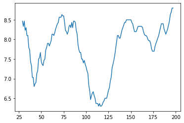

```python
s.plot()
```

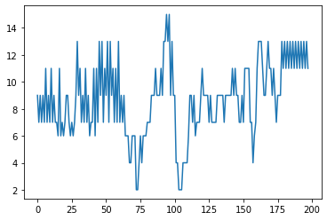

```python
future_data['WindSpeed'].astype(int).plot()

plt.figure(figsize=(10, 6))
```

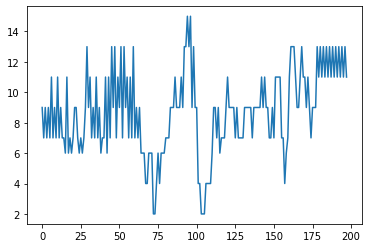

```python
future_data['WindSpeed'].astype(int).plot()
```

```python
future_data
```

|  | Unnamed: 0 | day | date | Max UV Index | Wind | Wind Gusts | Probability of Precipitation | Probability of Thunderstorms | Precipitation | Cloud Cover | Rain | Hours of Precipitation | Hours of Rain | WindSpeed |
| --- | --- | --- | --- | --- | --- | --- | --- | --- | --- | --- | --- | --- | --- | --- |
| 0 | 0 | 1 | Saturday, October 7 | 9 Very High | NNW 11 km/h | 33 km/h | 1% | 0% | 0.0 mm | 17% | NaN | NaN | NaN | 11 |
| 1 | 1 | 1 | Saturday, October 7 | NaN | NNW 9 km/h | 26 km/h | 1% | 0% | 0.0 mm | 17% | NaN | NaN | NaN | 9 |
| 2 | 2 | 2 | Sunday, October 8 | 8 Very High | NNW 13 km/h | 33 km/h | 1% | 0% | 0.0 mm | 6% | NaN | NaN | NaN | 13 |
| 3 | 3 | 2 | Sunday, October 8 | NaN | NNW 9 km/h | 24 km/h | 0% | 0% | 0.0 mm | 5% | NaN | NaN | NaN | 9 |
| 4 | 4 | 3 | Monday, October 9 | 8 Very High | NNW 13 km/h | 30 km/h | 0% | 0% | 0.0 mm | 11% | NaN | NaN | NaN | 13 |
| ... | ... | ... | ... | ... | ... | ... | ... | ... | ... | ... | ... | ... | ... | ... |
| 193 | 193 | 97 | Friday, January 5 | NaN | NE 9 km/h | 22 km/h | 0% | 0% | 0.0 mm | 51% | NaN | NaN | NaN | 9 |
| 194 | 194 | 98 | Friday, January 5 | 5 Moderate | ENE 9 km/h | 22 km/h | 0% | 0% | 0.0 mm | 16% | NaN | NaN | NaN | 9 |
| 195 | 195 | 98 | Friday, January 5 | NaN | NE 9 km/h | 22 km/h | 0% | 0% | 0.0 mm | 51% | NaN | NaN | NaN | 9 |
| 196 | 196 | 99 | Friday, January 5 | 5 Moderate | ENE 9 km/h | 22 km/h | 0% | 0% | 0.0 mm | 16% | NaN | NaN | NaN | 9 |
| 197 | 197 | 99 | Friday, January 5 | NaN | NE 9 km/h | 22 km/h | 0% | 0% | 0.0 mm | 51% | NaN | NaN | NaN | 9 |

198 rows × 14 columns

```python
future_data[future_data['date'] == 'Sunday, November 27']
```

|  | Unnamed: 0 | day | date | Max UV Index | Wind | Wind Gusts | Probability of Precipitation | Probability of Thunderstorms | Precipitation | Cloud Cover | Rain | Hours of Precipitation | Hours of Rain | WindSpeed |
| --- | --- | --- | --- | --- | --- | --- | --- | --- | --- | --- | --- | --- | --- | --- |

```python
future_data['WindSpeed']
```

[output not shown]

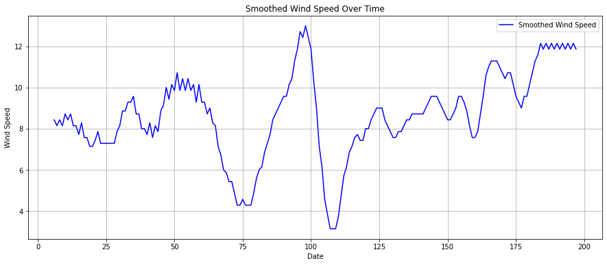

```python
# Convert 'WindSpeed' column to numeric if it's not already
# future_data['WindSpeed'] = pd.to_numeric(future_data['WindSpeed'], errors='coerce')
# future_data
# Calculate the rolling 7-day moving average
smoothed_wind_speed = future_data['WindSpeed'].rolling(window=7).mean()

# Plot the smoothed data
plt.figure(figsize=(15, 6))
plt.plot(future_data.index, smoothed_wind_speed, label='Smoothed Wind Speed', color='blue')
plt.xlabel('Date')
plt.ylabel('Wind Speed')
plt.title('Smoothed Wind Speed Over Time')
plt.legend()
plt.grid(True)
plt.show()
```

```python
MW Capacity=Voltage (kV)×Cables×Wires×0.001
```

```
  File "<ipython-input-133-cba9b179fbe6>", line 1
    MW Capacity=Voltage (kV)×Cables×Wires×0.001
       ^
SyntaxError: invalid syntax
```

```python
power_transmission_line = pd.read_excel('./scigrid-conference-eu-data-only/links_eu_power_160718.csvdata.xlsx')
# power_transmission_line
power_transmission_line['MW'] = (power_transmission_line['voltage'] * power_transmission_line['cables'] * power_transmission_line['wires']) * 0.000001
```

```python
power_transmission_line.sort_values("MW", ascending = False).iloc[0]['wkt_srid_4326']
```

```
'SRID=4326;LINESTRING(10.4012810931809 48.5146095739848,10.3917760727113 48.51846091102)'
```

```python
power_transmission_line
```

|  | l_id | v_id_1 | v_id_2 | voltage | cables | wires | frequency | name | operator | ref | length_m | r_ohmkm | x_ohmkm | c_nfkm | i_th_max_a | from_relation | wkt_srid_4326 | MW |
| --- | --- | --- | --- | --- | --- | --- | --- | --- | --- | --- | --- | --- | --- | --- | --- | --- | --- | --- |
| 0 | 1 | 1 | 2 | 220000 | 3.00 | 2.00 | 50.00 | Leitung 2016 | TenneT | 2016 | 43396 | 0.08 | 0.32 | 11.50 | 1.30 | 67129 | SRID=4326;LINESTRING(9.52257601112577 52.36040... | 1.32 |
| 1 | 2 | 3 | 4 | 380000 | 3.00 | 4.00 | 50.00 | Leitung 3011 | TenneT | NaN | 72714 | 0.03 | 0.25 | 13.70 | 2.60 | 67131 | SRID=4326;LINESTRING(9.38974515063535 52.02631... | 4.56 |
| 2 | 3 | 5 | 6 | 220000 | 3.00 | 2.00 | 50.00 | Leitung 2024 | TenneT | 1 | 33954 | 0.08 | 0.32 | 11.50 | 1.30 | 67151 | SRID=4326;LINESTRING(10.366274939217 52.284646... | 1.32 |
| 3 | 4 | 7 | 5 | 380000 | 3.00 | 4.00 | 50.00 | Leitung 3026 | TenneT | 3026 | 33483 | 0.03 | 0.25 | 13.70 | 2.60 | 67153 | SRID=4326;LINESTRING(9.9171797569037 52.278168... | 4.56 |
| 4 | 5 | 8 | 9 | 380000 | 6.00 | 4.00 | 50.00 | KKW Krümmel - UW Lüneburg | TenneT | NaN | 28172 | 0.01 | 0.12 | 27.40 | 5.20 | 67585 | SRID=4326;LINESTRING(10.4149924241538 53.41260... | 9.12 |
| ... | ... | ... | ... | ... | ... | ... | ... | ... | ... | ... | ... | ... | ... | ... | ... | ... | ... | ... |
| 2284 | 2285 | 1225 | 1477 | 225000 | NaN | NaN | 50.00 | NaN | RTE | NaN | 2808 | NaN | NaN | NaN | NaN | 6028654 | SRID=4326;LINESTRING(4.92805499306097 45.01922... | NaN |
| 2285 | 2286 | 1237 | 1477 | 225000 | NaN | NaN | 50.00 | NaN | RTE | NaN | 2376 | NaN | NaN | NaN | NaN | 6028654 | SRID=4326;LINESTRING(4.97631034285839 45.00140... | NaN |
| 2286 | 2287 | 1276 | 1479 | 400000 | NaN | NaN | 50.00 | NaN | RTE | NaN | 43673 | NaN | NaN | NaN | NaN | 6148806 | SRID=4326;LINESTRING(4.57287205721567 49.82747... | NaN |
| 2287 | 2288 | 1275 | 1479 | 400000 | NaN | NaN | 50.00 | NaN | RTE | NaN | 32176 | NaN | NaN | NaN | NaN | 6148806 | SRID=4326;LINESTRING(4.24055314711579 49.20151... | NaN |
| 2288 | 2289 | 1478 | 1479 | 400000 | NaN | NaN | 50.00 | NaN | RTE | NaN | 56 | NaN | NaN | NaN | NaN | 6148806 | SRID=4326;LINESTRING(4.43330825294337 49.45368... | NaN |

2289 rows × 18 columns

```python
power_statuion = pd.read_excel('./scigrid-conference-eu-data-only/vertices_eu_power_160718.csvdata.xlsx')
```

```python
power_statuion.value_counts('typ')
```

```
typ
substation          1334
auxillary_T_node      65
plant                 45
generator             23
dtype: int64
```

```python
power_statuion[power_statuion['wkt_srid_4326'] == 'SRID=4326;LINESTRING(10.4012810931809 48.5146095739848,10.3917760727113 48.51846091102)']
```

|  | v_id | lon | lat | typ | voltage | frequency | name | operator | ref | wkt_srid_4326 |
| --- | --- | --- | --- | --- | --- | --- | --- | --- | --- | --- |